# Case Study Unit #4: The Cherry Blossom Race

By: Armando Vela & Jeff Washburn

Date: 9/22/2020

## Abstract

Scraping web data, transforming the associated text, and creating a presentable dataframe was the topic of this case study. The data gathered and used was female ten-mile race data from the Cherry Blossom website. Techniques utilized throughout this case study include web scraping, function creation, regex pattern utilization, variable type modifications, and dataframe creation. Finally, we did not impute any 'NA' values as we left that up to the discretion of future researchers since it is outside the scope of the current assignment. With that said, the final dataframe is a great representation of the Cherry Blossom race data found within their website from 1999 through 2012.

## Introduction

Chapter 2 of the 'Data Science in R: A Case Studies Approach to Computational Reasoning and Problem Solving' text book, discusses using R to review the Cherry Blossom Race. With that in mind, Python was used to address the case study question and scrape female runner web data and place within a clean dataframe for future analysis.

The specific race data used was from the Credit Union Cherry Blossom Ten Mile Run at Washington D.C. and is located at www.cherryblossom.org. The years gathered and transformed are female ten-mile races from 1999-2012.

The Methods section below walks through the steps taken from how we scraped the race data and the necessary formatting & cleaning steps taken to create the final 'All Races' dataframe.

## Methods

#### Web Scraping

Data preparation for the Cherry Blossom race data required a variety of techniques to account for the different formats seen not only in a single file, but also the different formats across years.

Using Python, an API call was made to access each of the corresponding female race data’s HTML page. The extractResults function provided the parsing of the HTML race table data. We tried to be as generic as possible on parsing the race table data; however a couple of years did require special attention. For example, 2000, we had to look for a different identifier (face='Courier New') to pull the female’s race data placed after that specific tag.

See figures below comparing a Normal Scrape Example versus the Special Scrape Example.

**Figure 1: Normal Scrape Example (Year 2012)**

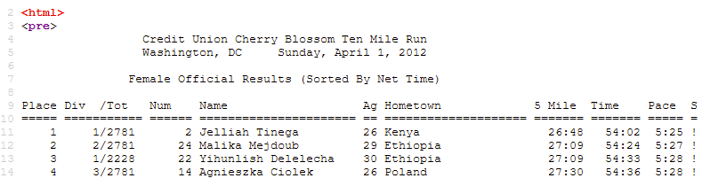

*FIGURE 1 NOTES: As you can see within the figure, the race data starts after the 'pre' tag.*

**Figure 2: Special Scrape Example (Year 2000)**

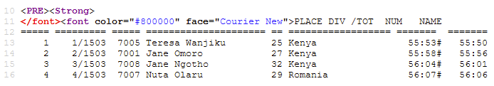

*FIGURE 2 NOTES: As you can see within the figure, the race data does not start until after the associated font tag.*

#### Data Processing

Once the female’s race data ascertained, we then processed each year’s data. To process each year, we initially started with the headerCleaner and splitIdentifier methods.

- The headerCleaner was used to remove unnecessary rows found at the beginning of the scraped data.
- The splitIdentifier was used to identify the appropriate string splits to separate the scraped data accordingly. To put it simply the function looked at the starting position of the table columns based on an indicator character of the equals sign (“=”). Using this approach, we could then identify the appropriate string lengths per column for each racer. This approach seemed to work for all the race data except for 2001.

To handle the 2001 data, we took a different approach and used regex patterns to process the data. Using the grouping mechanism of regex allowed us to easily process the 2001 race data while simultaneously creating a dataframe.

See figures below comparing a Normal Process Example (ie. 'Indicator Method) and why the Special Regex method was needed.

**Figure 3: Normal Processing 'Equal Sign Indicator Method' Example**

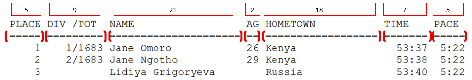

*FIGURE 3 NOTES: As you can see within the figure, the total number of equal signs shown under the header line was used to separate the text data for each column. In other words, for this example, as the formula went line by line through text, it was separating the first 5 characters into the 'Place' column, then separating the next 9 characters after the space into a 'Div/Tot' Column, and so on.*

**Figure 4: To Display Why Regex Processing Was Needed**

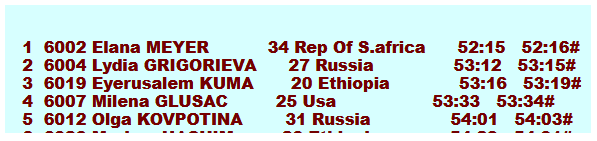

*FIGURE 4 NOTES: As you can see within the figure, there are no equal signs to count between the specific columns thus our normal processing formula would not work. The Regex method outlined in our code, walks through how we went about splitting this data.*

#### Creation of Initial Dataframes by Year & Combining Dataframes by Year into one "AllRaces" Dataframe

Once we identified the necessary splits using the non-Regex method, using the dataSplitter function we created a single dataframe that represented each year of the female race data.

Once we had each year parsed, we then needed to perform some additional cleanup such as renaming columns or removing extra rows that did not provide any valuable racing information.

Note the renaming of columns was necessary so that each dataframe year had matching column names. In other words, some races simply had Time, while other used Gun Time. By renaming the columns to match across the data frames allowed us to combine into a single data frame much simpler.

It is important to point out that no imputation was done for NA values. This was chosen to allow the researcher to modify/impute the data as they see fit.

```python
print('Figure 5: First 5 Rows of Final "AllRaces" Dataframe')
allRacesDf.head()
```

```
Figure 5: First 5 Rows of Final "AllRaces" Dataframe
```

|  | Place | Div_Total | Name | Age | Hometown | GunTime | Pace | Year | Num | Guidelines | NetTime | S | Split | 5Mile | 5MilePace | 10Km | 10KmPace |
| --- | --- | --- | --- | --- | --- | --- | --- | --- | --- | --- | --- | --- | --- | --- | --- | --- | --- |
| 0 | 1 | 1/1683 | Jane Omoro | 26 | Kenya | 53:37 | 5:22 | 1999 | NaN | NaN | NaN | NaN | NaN | NaN | NaN | NaN | NaN |
| 1 | 2 | 2/1683 | Jane Ngotho | 29 | Kenya | 53:38 | 5:22 | 1999 | NaN | NaN | NaN | NaN | NaN | NaN | NaN | NaN | NaN |
| 2 | 3 |  | Lidiya Grigoryeva |  | Russia | 53:40 | 5:22 | 1999 | NaN | NaN | NaN | NaN | NaN | NaN | NaN | NaN | NaN |
| 3 | 4 | 3/1683 | Eunice Sagero | 20 | Kenya | 53:55 | 5:24 | 1999 | NaN | NaN | NaN | NaN | NaN | NaN | NaN | NaN | NaN |
| 4 | 5 | 4/1683 | Alla Zhilyayeva | 29 | Russia | 54:08 | 5:25 | 1999 | NaN | NaN | NaN | NaN | NaN | NaN | NaN | NaN | NaN |

## Results

**Figure 6: Count of Participants by Year**

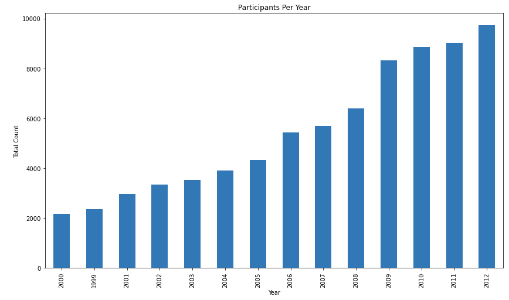

## Conclusion

Processing the Cherry Blossom race data for the female runners did have its challenges as mentioned above. Switching over to regex patterns proved to be useful and moving forward on future race data seems like a good alternative to pursue as it seems more straightforward and intuitive on how to process the data. In addition, using regex patterns, there are no additional lines that are added to the dataframe, only the lines that match the pattern are added.

In conclusion, we feel that having all the data combined into a single data frame will be useful for future analysis. Note, we are aware that additional steps can be taken within the dataframe (ie. imputations, adjust data types, feature creation) to further improve the information displayed.

## Appendix: Code Details

### Import necessary packages

```python
import requests
from bs4 import BeautifulSoup

import pandas as pd
import re
```

### Gather & format URLs for webscraping

```python
ubase = "http://www.cherryblossom.org/"

womenURLs = ["results/1999/cb99f.html",
    "results/2000/Cb003f.htm",
    "results/2001/oof_f.html",
    "results/2002/ooff.htm",
    "results/2003/CB03-F.HTM",
    "results/2004/women.htm",
    "results/2005/CB05-F.htm",
    "results/2006/women.htm",
    "results/2007/women.htm",
    "results/2008/women.htm",
    "results/2009/09cucb-F.htm",
    "results/2010/2010cucb10m-f.htm",
    "results/2011/2011cucb10m-f.htm",
    "results/2012/2012cucb10m-f.htm"]
```

```python
urls = []

for i in range(len(womenURLs)):
    urls.append(ubase + womenURLs[i])

urls
```

```
['http://www.cherryblossom.org/results/1999/cb99f.html',
 'http://www.cherryblossom.org/results/2000/Cb003f.htm',
 'http://www.cherryblossom.org/results/2001/oof_f.html',
 'http://www.cherryblossom.org/results/2002/ooff.htm',
 'http://www.cherryblossom.org/results/2003/CB03-F.HTM',
 'http://www.cherryblossom.org/results/2004/women.htm',
 'http://www.cherryblossom.org/results/2005/CB05-F.htm',
 'http://www.cherryblossom.org/results/2006/women.htm',
 'http://www.cherryblossom.org/results/2007/women.htm',
 'http://www.cherryblossom.org/results/2008/women.htm',
 'http://www.cherryblossom.org/results/2009/09cucb-F.htm',
 'http://www.cherryblossom.org/results/2010/2010cucb10m-f.htm',
 'http://www.cherryblossom.org/results/2011/2011cucb10m-f.htm',
 'http://www.cherryblossom.org/results/2012/2012cucb10m-f.htm']
```

### Formula Creation

- **extractResults():** Takes a list of websites from the cherry blossom race to download 1999-2012 race data for female participants.
- **headerCleaner():** Takes race data and removes unnecessary starting rows.
- **splitIdentifier():** Calculates start and end points to help separate text data.
- **dataSplitter():** Will run through and split txt data, place in list than convert to a dataframe. Note, function does not work for 2001, so another method was created to clean this data.
- **regexSplitter():** Will run through and split txt data using specified regex pattern. Helpful with parsing 2001 data.

```python
def extractResults():
    """
    Name: extractResults function
    Purpose: Takes a list of websites from the cherry blossom race to download 1999-2012 race data for female participants.
    Parameters: NONE
    Packages/Functions Needed: Requires 'requests' and 'BeautifulSoup' libraries
    Return Output: dictionary listing year of race and corresponding race results
    """

    #empty dictionary that will be filled in with year and associated race results.
    resultsDictionary = {}

    #empty list that will be filled in with associated race results
    resultsList = []

    for i in urls:
        yr = i[37:41]

        print(f'Working on {yr}!')

        #retrieve data from web site
        page = requests.get(i)

        #perform initial html parsing
        soup = BeautifulSoup(page.content, 'html.parser')

        if yr == '2000':
            #Year 2000 race does not have 'pre' tag.  Used a different identifier to locate text.
            results_info_with_tag = soup.find(face="Courier New")
        else:
            #identify race results with tag
            results_info_with_tag = soup.find('pre')

        #gather race data
        race_text = results_info_with_tag.get_text()

        #split string into different lines
        race_data_list = race_text.splitlines()

        #append race_data_list to resultsList
        resultsList.append(race_data_list)


    for idx in range(len(resultsList)):
        #create year variable to include as the dictionary key. Converted to string for dictionary purposes.
        year = 1999 + idx
        year = str(year)

        #combine year and results list into one dictionary
        resultsDictionary[year] = resultsList[idx]

    #return dictionary with year and race results
    return(resultsDictionary)
```

```python
def headerCleaner(data):
    """
    Name: headerCleaner function
    Purpose: Removes unnecessary header information from race data.
    Parameters: race results data
    Packages/Functions Needed: NONE
    Return Output: dictionary listing year of race and corresponding race results
    """
    cleanDictionary = {}
    raceData = data

    for idx in range(len(raceData)):
        #create year variable to include as the dictionary key. Converted to string for dictionary purposes.
        year = 1999 + idx
        year = str(year)
        race = raceData[year]
        char = 0

        if year == '2001':
            cleanDictionary[year] = race[3:]
        else:
            for j in range(len(race)):

                if race[j] == '':
                    pass
                elif race[j][0].isalpha() and char ==0:
                    #combine year and results list into one dictionary
                    cleanDictionary[year] = race[j:]
                    char = 1


    #creturn clean dictionary
    return(cleanDictionary)
```

```python
def splitIdentifier(data):
    """
    Name: splitIdentifier function
    Purpose: Takes race data, idenfities location of '=' sign, provides the location where there is a space between each '='
    Parameters: race results data
    Packages/Functions Needed: Requires 'pandas' library
    Return Output: dictionary listing year of race and corresponding index where a space was found between text columns
    """
    raceData = data
    indexerDf = pd.DataFrame(columns=('year','idx','count'))
    years = list(raceData.keys())

    #iterate over list of years and gather row index where '=' are listed
    for i in years:
        tempData = raceData[i]

        for k in range(len(raceData[i])):
            count = raceData[i][k].count('=')

            if count > 0:
                indexerDf = indexerDf.append({'year': i ,'idx' : k,'count' : count}, ignore_index=True)



    #get dictionary of all breaks in (ie. spaces) between columns to help separate the race results information
    line_idx_dictionary = {}

    for row in range(len(indexerDf)):
        row_year = indexerDf.iloc[row,0]
        row_idx = indexerDf.iloc[row,1]
        line_idx_list = []

        for x in range(len(raceData[row_year][row_idx])):
            line_idx = raceData[row_year][row_idx].find(' ', x)

            if line_idx == x:
                line_idx_list.append(line_idx)

        line_idx_dictionary[row_year] = line_idx_list

    return(line_idx_dictionary)
```

```python
def dataSplitter(data, year):
    """
    Name: dataSplitter function
    Purpose: Takes race data, uses splitIdentifier() function to split columns and place within a returned dataframe
    Parameters: data, year
    Packages/Functions Needed: Requires 'pandas' library
    Return Output: dataframe of race data
    """
    raceData = data[str(year)]

    raceResultsDictionary = {}
    #raceResultsList = []

    splitID = splitIdentifier(data)
    splitsByYr = splitID[str(year)]

    df = pd.DataFrame()

    if year == '2003':
        adjuster_if_2003 = 1
    else:
        adjuster_if_2003 = 0


    for x in range(len(raceData)):

        if x==0:
            titleList = []

            for s in range(len(splitsByYr)):
                if s==0:
                    titleList.append(raceData[x][0:splitsByYr[s] + adjuster_if_2003])
                else:
                    titleList.append(raceData[x][splitsByYr[s-1] + adjuster_if_2003:splitsByYr[s] + adjuster_if_2003])

        elif x==1 and raceData[x].startswith('='):
            pass

        else:

            raceResultsList = []

            for s in range(len(splitsByYr)):
                if s==0:
                    raceResultsList.append(raceData[x][0:splitsByYr[s] + adjuster_if_2003])
                else:
                    raceResultsList.append(raceData[x][splitsByYr[s-1] + adjuster_if_2003:splitsByYr[s] + adjuster_if_2003])

            df = df.append(pd.DataFrame(raceResultsList).transpose(), ignore_index=True)

    df.columns = titleList

    return(df)
```

```python
def regexSplitter(data, year):
    """
    Name: regexSplitter function
    Purpose: Takes race data, uses RegEx patter to split into columns and return dataframe
    Parameters: data, year
    Packages/Functions Needed: Requires 'pandas' library, and 're' library
    Return Output: dataframe of race data
    """
    raceData = data[str(year)]

    pattern2001 = "\\s+(\\d+)\\s+(\\d+)\\s+((?:[A-Za-z\\-\\.\\'\\` ]{1,25} ?\\b){1,4})\\s+(\\d+)\\s+((?:[A-Za-z\\-\\.\\'\\` ]{1,25} ?\\b){1,4})\\s+((?:(?:\\d+:){1,3}(?:\\d+)))\\s+((?:(?:\\d+:){1,3}(?:\\d+)))"

    df = pd.DataFrame()


    for x in range(len(raceData) - 1):

        row = list(re.findall(pattern2001, raceData[x])[0])

        df = df.append(pd.DataFrame(row).transpose(), ignore_index=True)


    df.columns = ['Place', 'Num', 'Name', 'Age', 'Hometown', 'NetTime', 'GunTime']


    return (df)
```

### Scrape URL Data using extractResults function

```python
#run extractResults function to gather race data
raceInfo = extractResults()
```

```
Working on 1999!
Working on 2000!
Working on 2001!
Working on 2002!
Working on 2003!
Working on 2004!
Working on 2005!
Working on 2006!
Working on 2007!
Working on 2008!
Working on 2009!
Working on 2010!
Working on 2011!
Working on 2012!
```

```python
#print out length of lines for each year
for j in raceInfo:
    l = len(raceInfo[j])
    print(f'year: {j}, length: {l}')
```

```
year: 1999, length: 2359
year: 2000, length: 2169
year: 2001, length: 2976
year: 2002, length: 3338
year: 2003, length: 3547
year: 2004, length: 3907
year: 2005, length: 4342
year: 2006, length: 5445
year: 2007, length: 5699
year: 2008, length: 6405
year: 2009, length: 8333
year: 2010, length: 8863
year: 2011, length: 9038
year: 2012, length: 9737
```

### Run headerCleaner to remove unnecessary starting rows

```python
raceInfoEdit = headerCleaner(raceInfo)
```

### Gather splits using splitIdentifier and run dataSplitter and regexSplitter to place yearly race data into separate dataframes

```python
splits = splitIdentifier(raceInfoEdit)
splits
```

```
{'1999': [5, 15, 37, 40, 59, 67, 73],
 '2000': [5, 15, 21, 43, 46, 65, 73, 74, 82],
 '2002': [5, 11, 33, 36, 55, 63, 71],
 '2003': [5, 15, 21, 51, 54, 74, 82, 83, 91],
 '2004': [5, 15, 21, 51, 54, 74, 82, 90],
 '2005': [5, 15, 38, 41, 60, 68, 76, 82],
 '2006': [5, 14, 21, 44, 47, 71, 79, 80, 86, 88],
 '2007': [5, 17, 24, 47, 50, 69, 77, 78, 84, 86, 94],
 '2008': [5, 17, 24, 47, 50, 69, 77, 83, 91, 97, 105, 111],
 '2009': [5, 17, 24, 47, 50, 71, 79, 87, 88, 94, 96],
 '2010': [5, 17, 24, 47, 50, 71, 79, 87, 95, 96, 102, 104],
 '2011': [5, 17, 24, 47, 50, 71, 79, 87, 95, 101, 103],
 '2012': [5, 17, 24, 47, 50, 71, 79, 87, 93, 95]}
```

```python
#split rows of data and create dataframe for each year
race1999 = dataSplitter(raceInfoEdit,'1999')
race2000 = dataSplitter(raceInfoEdit,'2000')
race2001 = regexSplitter(raceInfoEdit,'2001')
race2002 = dataSplitter(raceInfoEdit,'2002')
race2003 = dataSplitter(raceInfoEdit,'2003')
race2004 = dataSplitter(raceInfoEdit,'2004')
race2005 = dataSplitter(raceInfoEdit,'2005')
race2006 = dataSplitter(raceInfoEdit,'2006')
race2007 = dataSplitter(raceInfoEdit,'2007')
race2008 = dataSplitter(raceInfoEdit,'2008')
race2009 = dataSplitter(raceInfoEdit,'2009')
race2010 = dataSplitter(raceInfoEdit,'2010')
race2011 = dataSplitter(raceInfoEdit,'2011')
race2012 = dataSplitter(raceInfoEdit,'2012')
```

### Yearly dataframe cleanup prior to merging (ie. Rename columns - Clean unnecessary rows)

```python
#Rename columns so they correlate with each other
race1999.columns = ['Place', 'Div_Total', 'Name', 'Age', 'Hometown', 'GunTime', 'Pace']
race2000.columns = ['Place', 'Div_Total', 'Num', 'Name', 'Age', 'Hometown', 'GunTime', 'Guidelines', 'NetTime']
race2001.columns = ['Place', 'Num', 'Name', 'Age', 'Hometown', 'NetTime', 'GunTime']
race2002.columns = ['Place', 'Num', 'Name', 'Age', 'Hometown', 'NetTime', 'GunTime']
race2003.columns = ['Place', 'Div_Total', 'Num', 'Name', 'Age', 'Hometown', 'GunTime', 'Guidelines', 'NetTime']
race2004.columns = ['Place', 'Div_Total', 'Num', 'Name', 'Age', 'Hometown', 'NetTime', 'GunTime']
race2005.columns = ['Place', 'Div_Total', 'Name', 'Age', 'Hometown', 'NetTime', 'GunTime', 'Pace']
race2006.columns = ['Place', 'Div_Total', 'Num', 'Name', 'Age', 'Hometown', 'NetTime', 'GunTime', 'Guidelines', 'Pace']
race2007.columns = ['Place', 'Div_Total', 'Num', 'Name', 'Age', 'Hometown', 'GunTime', 'Guidelines', 'Pace', 'S', 'Split']
race2008.columns = ['Place', 'Div_Total', 'Num', 'Name', 'Age', 'Hometown', '5Mile', '5MilePace', '10Km', '10KmPace', 'GunTime', 'Pace']
race2009.columns = ['Place', 'Div_Total', 'Num', 'Name', 'Age', 'Hometown', 'GunTime','NetTime', 'Guidelines', 'Pace', 'S']
race2010.columns = ['Place', 'Div_Total', 'Num', 'Name', 'Age', 'Hometown', '5Mile', 'GunTime', 'NetTime', 'Guidelines', 'Pace','S']
race2011.columns = ['Place', 'Div_Total', 'Num', 'Name', 'Age', 'Hometown', '5Mile', 'GunTime', 'NetTime', 'Pace','S']
race2012.columns = ['Place', 'Div_Total', 'Num', 'Name', 'Age', 'Hometown', '5Mile', 'GunTime', 'Pace', 'S']
```

```python
#clean tail of dataframe
#removing either last row or last two rows of dataframe
race2000 = race2000[:-1].copy()
race2002 = race2002[:-1].copy()
race2003 = race2003[:-2].copy()
race2005 = race2005[:-1].copy()
race2006 = race2006[:-2].copy()
race2007 = race2007[:-2].copy()
race2009 = race2009[:-2].copy()
race2010 = race2010[:-2].copy()
```

```python
#add year column so that yearly dataframes can be combined into one large dataframe
race1999['Year'] = 1999
race2000['Year'] = 2000
race2001['Year'] = 2001
race2002['Year'] = 2002
race2003['Year'] = 2003
race2004['Year'] = 2004
race2005['Year'] = 2005
race2006['Year'] = 2006
race2007['Year'] = 2007
race2008['Year'] = 2008
race2009['Year'] = 2009
race2010['Year'] = 2010
race2011['Year'] = 2011
race2012['Year'] = 2012
```

### Append all race data into new dataframe

```python
#combine all yearly dataframes and reset index
allRacesDf = race1999.append([race2000, race2001, race2002, race2003, race2004, race2005, race2006, race2007, race2008,
                              race2009, race2010, race2011, race2012]).reset_index(drop=True)
```

```python
allRacesDf
```

|  | Place | Div_Total | Name | Age | Hometown | GunTime | Pace | Year | Num | Guidelines | NetTime | S | Split | 5Mile | 5MilePace | 10Km | 10KmPace |
| --- | --- | --- | --- | --- | --- | --- | --- | --- | --- | --- | --- | --- | --- | --- | --- | --- | --- |
| 0 | 1 | 1/1683 | Jane Omoro | 26 | Kenya | 53:37 | 5:22 | 1999 | NaN | NaN | NaN | NaN | NaN | NaN | NaN | NaN | NaN |
| 1 | 2 | 2/1683 | Jane Ngotho | 29 | Kenya | 53:38 | 5:22 | 1999 | NaN | NaN | NaN | NaN | NaN | NaN | NaN | NaN | NaN |
| 2 | 3 |  | Lidiya Grigoryeva |  | Russia | 53:40 | 5:22 | 1999 | NaN | NaN | NaN | NaN | NaN | NaN | NaN | NaN | NaN |
| 3 | 4 | 3/1683 | Eunice Sagero | 20 | Kenya | 53:55 | 5:24 | 1999 | NaN | NaN | NaN | NaN | NaN | NaN | NaN | NaN | NaN |
| 4 | 5 | 4/1683 | Alla Zhilyayeva | 29 | Russia | 54:08 | 5:25 | 1999 | NaN | NaN | NaN | NaN | NaN | NaN | NaN | NaN | NaN |
| ... | ... | ... | ... | ... | ... | ... | ... | ... | ... | ... | ... | ... | ... | ... | ... | ... | ... |
| 76054 | 9726 | 973/974 | Khristina Nava | 40 | Fort Meade MD | 2:33:11 | 15:20 | 2012 | 19016 | NaN | NaN |  | NaN | 1:14:03 | NaN | NaN | NaN |
| 76055 | 9727 | 2228/2228 | Geneva Dixon | 31 | Manassas Park VA | 2:36:03 | 15:37 | 2012 | 8258 | NaN | NaN |  | NaN | 1:14:26 | NaN | NaN | NaN |
| 76056 | 9728 | 236/236 | Veronica Eligan | 55 | Mitchellville MD | 2:36:45 | 15:41 | 2012 | 23195 | NaN | NaN |  | NaN | 1:28:21 | NaN | NaN | NaN |
| 76057 | 9729 | 974/974 | Denise Bobba | 40 | Herndon VA | 2:36:54 | 15:42 | 2012 | 17855 | NaN | NaN |  | NaN | 1:15:18 | NaN | NaN | NaN |
| 76058 | 9730 | 1366/1366 | Rashonna Waples | 38 | District Heights MD | 2:50:58 | 17:06 | 2012 | 24256 | NaN | NaN |  | NaN | 1:28:38 | NaN | NaN | NaN |

76059 rows × 17 columns

### Plot count of participants by year

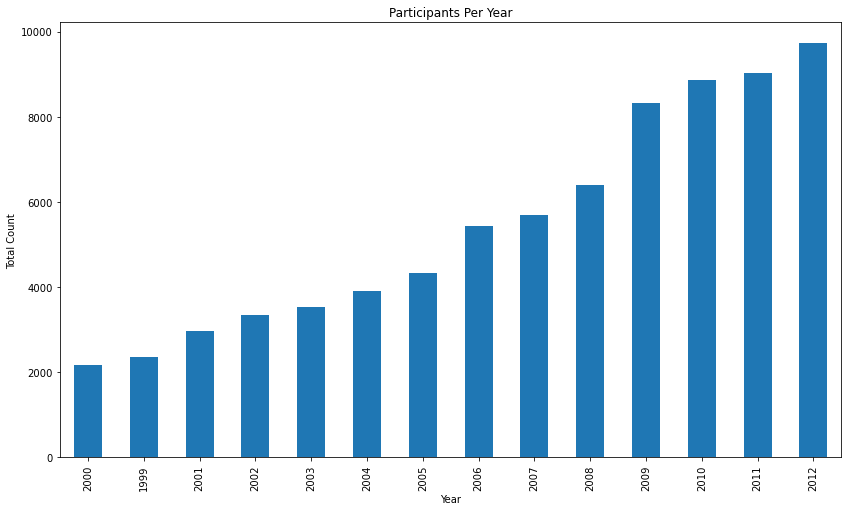

```python
ax = allRacesDf['Year'].value_counts().sort_values().plot(kind='bar',
                                    figsize=(14,8),
                                    title="Participants Per Year")
ax.set_xlabel("Year")
ax.set_ylabel("Total Count")
```